# Eigenprism

Charles Zheng

05/22/2015

See Janson et al 2015 http://arxiv.org/pdf/1505.02097v1.pdf

Problem setup. Goal: estimate $\theta^2 = ||\beta||^2$.

```r
library(pracma)
library(magrittr)
library(MASS)
n <- 100
p <- 200
Sigma_X <- (1/(2 * p)) * (randn(2 * p, p) %>% {t(.) %*% .})
X <- mvrnorm(n, mu = rep(0, p), Sigma = Sigma_X)
b <- rnorm(p)
y <- X %*% b + 0.1 * rnorm(n)
norm_b <- sum(b^2)
norm_b
```

```
## [1] 197.4227
```

Quantities needed for eigenprism

```r
res <- svd(X)
dim(res$u)
```

```
## [1] 100 100
```

```r
z <- t(res$u) %*% y
l <- res$d^2/p #lambdas
```

Eigenprism optimization problem $\text{minimize}_w \max\{\sum_{i=1}^n w_i^2, \sum_{i=1}^n w_i^2 \lambda_i^2\} \text{ such that }1^T w = 0, \lambda^T w = 1$

Here a simple algorithm for solving the optimization problem. Let $f_i(w) = w^T \Lambda_i w$, for $i = 0, 1$, where $\Lambda_0 = I$ and $\Lambda_1 = \text{diag}(\lambda)$, so that $f = \max(f_0, f_1)$. Let $L = [1, \lambda]$ and let $P = I - L(L^T L )^{1} L$ (the projection onto subspace of allowed directions).

Beginning at some feasible $w = w_0$, evaluate the constrained Newton direction $g$. (Any $w - t g$ is feasible.) Let $\iota = 1$ if $f_1 > f_2$ and $\iota = 2$ otherwise. Now, instead of doing a line search, we only check up to 3 distinct values of $t$. We will solve for $t_{min}$ which minimizes $f_\iota(w - t g)$ and also solve for $t_{eq}$ such that $f_1(w - t g) = f_2(w - t g)$ (if possible). It may also be possible that $t_{eq}$ has two solutions, in which case we check both. Note that $f_1(w - tg) = ||w||^2 - 2t w^T g + t^2 ||g||^2$ $f_2(w - tg) = ||(w\circ \lambda)||^2 - 2t (w \circ \lambda)^T (g\circ \lambda) + t^2 ||(g \circ \lambda)||^2$ Hence expressions for $t_{min}$ and $t_{eq}$ are easily obtained.

```r
# Get an initial point
w0 <- 1/(l[1] - l[2]) * c(1, -1, rep(0, n - 2))
w <- w0
# objective function
f <- function(w) {
  max(sum(w^2), sum((w * l)^2))
}
f(w)
```

```
## [1] 402.8508
```

```r
# Form the null space where we are free to move
res <- svd(cbind(1, l))
P <- -(res$u %>% {(.) %*% t(.)})
diag(P) <- diag(P) + 1
A <- P[, -c(1, 2)]
# Newton operators
Ls <- list(diag(rep(1, n)), diag(l))
Ns <- lapply(Ls, function(L) A %*% solve(t(A) %*% L %*% A) %*% t(A) %*% L)
tz <- 0:200/100
```

Iteration demo (run this yourself…)

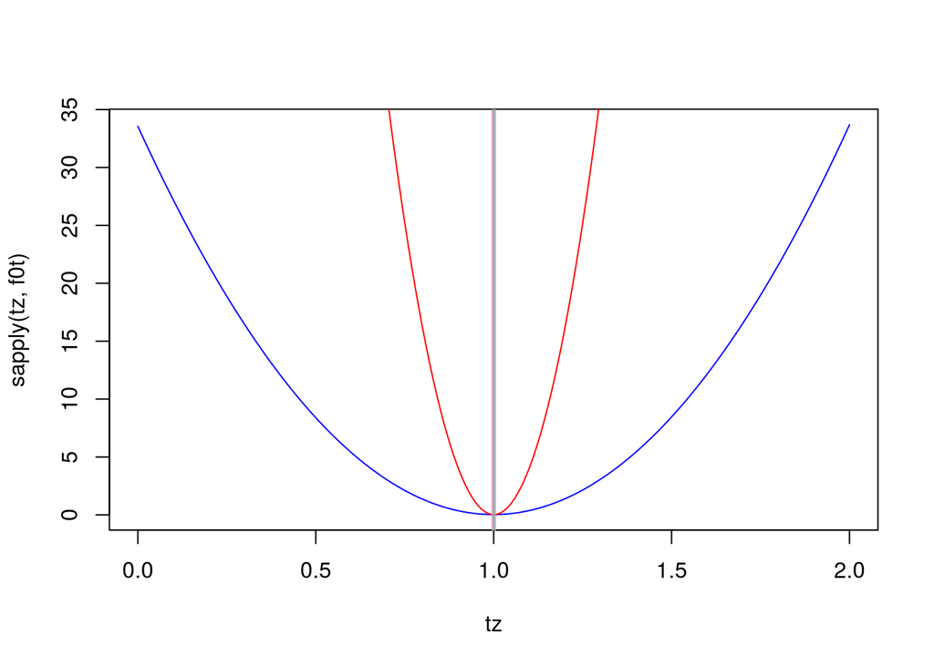

```r
## LOOP
# evaluate the gradient
f_flag <- sum(w^2) < sum((w * l)^2)
lterm <- l^(2 * f_flag)
# constrained Newton direction
g <- Ns[[1 + f_flag]] %*% w
# t_minimize and t_eq
t_min <- sum(w * g * lterm)/(sum(g^2 * lterm) + 1e-10)
aa <- sum(g ^ 2) - sum((g * l)^2)
bb <- -2 * (sum(g * w) - sum(l^2 * g * w))
cc <- sum(w^2) - sum((w * l)^2)
suppressWarnings({t_eq <- (-bb + c(-1, 1)*sqrt(bb^2 - 4 * aa * cc))/(2 * aa)})
ts <- c(t_min, t_eq[!is.na(t_eq)])
vals <- sapply(ts, function(t) f(w - t * g))
t_best <- ts[order(vals)[1]]

f0t <- function(t) sum((w - t * g)^2)
f1t <- function(t) sum((w - t * g)^2 * l^2)
plot(tz, sapply(tz, f0t), type = "l", col = "blue")
lines(tz, sapply(tz, f1t), col = "red")
abline(v = t_min, col = "green")
if (sum(!is.na(t_eq)) > 0) abline(v = t_eq[!is.na(t_eq)], col = "violet")
```

```r
w <- w - t_best * g
print(list(f_flag, ts, vals, f(w)))
```

```
## [[1]]
## [1] TRUE
##
## [[2]]
## [1] 1.0001790 1.0042407 0.9963339
##
## [[3]]
## [1] 0.03443267 0.03531131 0.03462185
##
## [[4]]
## [1] 0.03443267
```

The function for finding w

```r
eigenprism_w <- function(l, tol = 1e-4) {
  n <- length(l)
  f <- function(w) max(sum(w^2), sum((w * l)^2))
  # null space directions
  res <- svd(cbind(1, l))
  P <- -(res$u %>% {(.) %*% t(.)})
  diag(P) <- diag(P) + 1
  A <- P[, -c(1, 2)]
  # Newton operators
  Ls <- list(diag(rep(1, n)), diag(l))
  Ns <- lapply(Ls, function(L) A %*% solve(t(A) %*% L %*% A) %*% t(A) %*% L)
  # initialization
  w <- 1/(l[1] - l[2]) * c(1, -1, rep(0, n - 2))
  f_old <- f(w)
  iter_flag <- TRUE
  while(iter_flag) {
    # evaluate the gradient
    f_flag <- sum(w^2) < sum((w * l)^2)
    lterm <- l^(2 * f_flag)
    # constrained Newton direction
    g <- Ns[[1 + f_flag]] %*% w
    # t_minimize and t_eq
    t_min <- sum(w * g * lterm)/(sum(g^2 * lterm) + 1e-10)
    aa <- sum(g ^ 2) - sum((g * l)^2)
    bb <- -2 * (sum(g * w) - sum(l^2 * g * w))
    cc <- sum(w^2) - sum((w * l)^2)
    suppressWarnings({t_eq <- (-bb + c(-1, 1)*sqrt(bb^2 - 4 * aa * cc))/(2 * aa)})
    ts <- c(t_min, t_eq[!is.na(t_eq)])
    vals <- sapply(ts, function(t) f(w - t * g))
    t_best <- ts[order(vals)[1]]
    w <- w - t_best * g
    f_new <- min(vals)
    if (f_old - f_new < tol) iter_flag <- FALSE
    f_old <- f_new
  }
  list(w = w, val = f_old)
}

eigenprism <- function(X, y, alpha = 0.05) {
  n <- length(y)
  res <- svd(X)
  dim(res$u)
  z <- t(res$u) %*% y
  l <- res$d^2/p
  res <- eigenprism_w(l)
  w <- res$w; val <- res$val
  T2 <- sum(z^2 * w)
  qq <- qnorm(1 - alpha/2)
  width <- qq * sqrt(2 * val) * sum(y^2)/n
  lower <- max(T2 - width, 0)
  upper <- T2 + width
  list(T2 = T2, lower = lower, upper = upper)
}
```

Application to regression problem:

```r
norm_b
```

```
## [1] 197.4227
```

```r
eigenprism(X, y)
```

```
## $T2
## [1] 204.7277
##
## $lower
## [1] 112.2856
##
## $upper
## [1] 297.1697
```